# Cap. 1: The tidytext format

Macarena Quiroga

12/24/2021

> Este texto es una traducción adaptada por mí del libro [Text Mining with R](https://www.tidytextmining.com/preface.html) de Julia Silge y David Robinson.

El concepto clave para esta primera parte es el de **token**, que es una unidad significativa de análisis. Puede ser una palabra, una oración, etc.; lo que se necesite. Luego se presentan los conceptos de *cadena [string]*, *corpus* y *matriz de los términos del documento [document-term matrix]*.

Primero vamos a trabajar con la forma básica de convertir un texto a formato tidy. Podemos armar un objeto tipo cadena:

```r
text <- c("Because I could not stop for Death -",
          "He kindly stopped for me -",
          "The Carriage held but just Ourselves -",
          "and Immortality")
text
```

```
## [1] "Because I could not stop for Death -"
## [2] "He kindly stopped for me -"
## [3] "The Carriage held but just Ourselves -"
## [4] "and Immortality"
```

Podemos convertirlo en un dataframe, agregando una columna que indique los números de líneas:

```r
library(dplyr)
text_df <- tibble(line = 1:4, text = text)
text_df
```

```
## # A tibble: 4 × 2
##    line text
##   <int> <chr>
## 1     1 Because I could not stop for Death -
## 2     2 He kindly stopped for me -
## 3     3 The Carriage held but just Ourselves -
## 4     4 and Immortality
```

Una vez que tenemos esto, podemos separar los versos de forma tal que cada fila sea una palabra, sin perder la referencia del orden de los versos. Para eso usamos la función `unnest_tokens()`: el primer argumento es el nombre de la nueva columna que contendrá los tokens, y la segunda es la columna del df de donde hay que tomar los tokens. Se retienen las otras columnas, se borran los signos de puntuación y convierte todas las palabras a minúsculas (esto se puede evitar con `to_lower = FALSE`).

```r
library(tidytext)
text_df %>%
  unnest_tokens(word, text)
```

```
## # A tibble: 20 × 2
##     line word
##    <int> <chr>
##  1     1 because
##  2     1 i
##  3     1 could
##  4     1 not
##  5     1 stop
##  6     1 for
##  7     1 death
##  8     2 he
##  9     2 kindly
## 10     2 stopped
## 11     2 for
## 12     2 me
## 13     3 the
## 14     3 carriage
## 15     3 held
## 16     3 but
## 17     3 just
## 18     3 ourselves
## 19     4 and
## 20     4 immortality
```

## Paquete `janeaustenr`

Este paquete presenta el contenido de las seis novelas de Jane Austen con un formato de una fila por línea de texto. A continuación vamos a agregar un número de línea para no perder registro y vamos a anotar los capítulos. La función `cumsum()` devuelve la suma acumulada de los elementos del objeto numérico que se da como argumento; en este caso, tiene como argumento la detección de una cadena de texto que tenga la cadena “chapter”.

```r
library(janeaustenr)
library(dplyr)
library(stringr)

original_books <- austen_books() %>%
  group_by(book) %>%
  mutate(linenumber = row_number(),
         chapter = cumsum(str_detect(text,
                                     regex("^chapter [\\divxlc]",
                                           ignore_case = TRUE)))) %>%
  ungroup()

original_books
```

```
## # A tibble: 73,422 × 4
##    text                    book                linenumber chapter
##    <chr>                   <fct>                    <int>   <int>
##  1 "SENSE AND SENSIBILITY" Sense & Sensibility          1       0
##  2 ""                      Sense & Sensibility          2       0
##  3 "by Jane Austen"        Sense & Sensibility          3       0
##  4 ""                      Sense & Sensibility          4       0
##  5 "(1811)"                Sense & Sensibility          5       0
##  6 ""                      Sense & Sensibility          6       0
##  7 ""                      Sense & Sensibility          7       0
##  8 ""                      Sense & Sensibility          8       0
##  9 ""                      Sense & Sensibility          9       0
## 10 "CHAPTER 1"             Sense & Sensibility         10       1
## # … with 73,412 more rows
```

Ahora sí podemos pasar al formato de una palabra por fila. Esta función viene del paquete tokenizers que permite tokenizar otras cosas, como líneas, caracteres, párrafos, oraciones, raíces léxicas, etc.

```r
library(tidytext)
tidy_books <- original_books %>%
  unnest_tokens(word, text)
```

Se pueden quitar las palabras vacías (“stop words”), como los artículos o preposiciones, que están presente en el dataset `stop_words` dentro del paquete `tidytext`.

```r
data("stop_words")
tidy_books <- tidy_books %>%
  anti_join(stop_words)
```

Ahora podemos contar las palabras más frecuentes:

```r
tidy_books %>%
  count(word, sort = TRUE)
```

```
## # A tibble: 13,914 × 2
##    word       n
##    <chr>  <int>
##  1 miss    1855
##  2 time    1337
##  3 fanny    862
##  4 dear     822
##  5 lady     817
##  6 sir      806
##  7 day      797
##  8 emma     787
##  9 sister   727
## 10 house    699
## # … with 13,904 more rows
```

Y hacer gráficos:

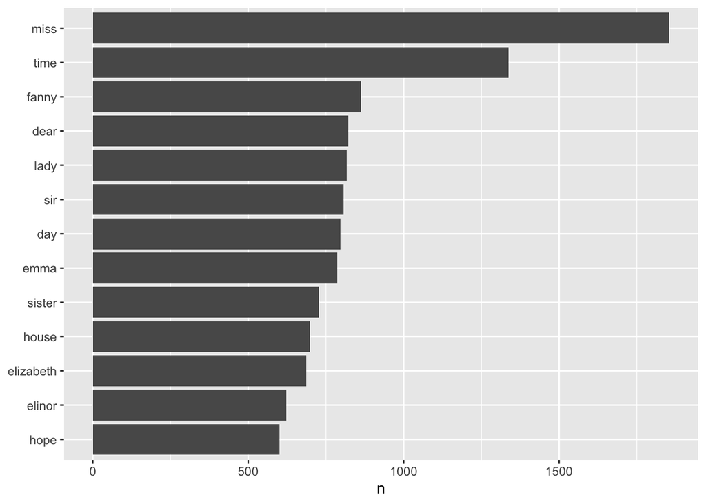

```r
library(ggplot2)
tidy_books %>%
  count(word, sort = TRUE) %>%
  filter(n > 600) %>%
  mutate(word = reorder(word, n)) %>%
  ggplot(aes(n, word)) +
  geom_col()+
  labs(y = NULL)
```

## Paquete `gutenbergr`

[Este paquete](https://docs.ropensci.org/gutenbergr/) nos da acceso a todas las obras de dominio público que forman parte del Proyecto Gutenberg, junto con herramientas para descargar libros y con metadata. Ahora vamos a trabajar con cuatro obras de H.G. Wells para contar frecuencias y compararlas entre sí.

```r
library(gutenbergr)
hgwells <- gutenberg_download(c(35, 36, 5230, 159)) # selecciona el ID
```

```
## Determining mirror for Project Gutenberg from http://www.gutenberg.org/robot/harvest
```

```
## Using mirror http://aleph.gutenberg.org
```

```r
tidy_hgwells <- hgwells %>%
  unnest_tokens(word, text) %>%
  anti_join(stop_words)
tidy_hgwells %>%
  count(word, sort = TRUE)
```

```
## # A tibble: 11,811 × 2
##    word       n
##    <chr>  <int>
##  1 time     461
##  2 people   302
##  3 door     260
##  4 heard    249
##  5 black    232
##  6 stood    229
##  7 white    224
##  8 hand     218
##  9 kemp     213
## 10 eyes     210
## # … with 11,801 more rows
```

Lo mismo hace con cinco novelas de las hermanas Brontë:

```r
bronte <- gutenberg_download(c(1260, 768, 969, 9182, 767))
tidy_bronte <- bronte %>%
  unnest_tokens(word, text) %>%
  anti_join(stop_words)
tidy_bronte %>%
  count(word, sort = TRUE)
```

```
## # A tibble: 23,297 × 2
##    word       n
##    <chr>  <int>
##  1 time    1065
##  2 miss     854
##  3 day      825
##  4 hand     767
##  5 eyes     714
##  6 don’t    666
##  7 night    648
##  8 heart    638
##  9 looked   601
## 10 door     591
## # … with 23,287 more rows
```

Ahora que tenemos estas frecuencias calculadas, podemos compararlas entre las obras:

```r
library(tidyr)
frequency <- bind_rows(mutate(tidy_bronte, author = "Brontë Sisters"), # agrega una columna de autor en cada
                       mutate(tidy_hgwells, author = "H.G. Wells"),
                       mutate(tidy_books, author = "Jane Austen")) %>%
  mutate(word = str_extract(word, "[a-z']+")) %>% # quita lo que no son palabras (números o símbolos)
  count(author, word) %>% # cuenta las palabras por autor
  group_by(author) %>%
  mutate(proportion = n / sum(n)) %>% # proporción de cada palabra respecto del total de palabras
  select(-n) %>%
  pivot_wider(names_from = author, values_from = proportion) %>%
  pivot_longer(`Brontë Sisters`:`H.G. Wells`,
               names_to = "author", values_to = "proportion")
frequency
```

```
## # A tibble: 57,116 × 4
##    word      `Jane Austen` author          proportion
##    <chr>             <dbl> <chr>                <dbl>
##  1 a            0.00000919 Brontë Sisters  0.0000587
##  2 a            0.00000919 H.G. Wells      0.0000147
##  3 aback       NA          Brontë Sisters  0.00000391
##  4 aback       NA          H.G. Wells      0.0000147
##  5 abaht       NA          Brontë Sisters  0.00000391
##  6 abaht       NA          H.G. Wells     NA
##  7 abandon     NA          Brontë Sisters  0.0000313
##  8 abandon     NA          H.G. Wells      0.0000147
##  9 abandoned    0.00000460 Brontë Sisters  0.0000900
## 10 abandoned    0.00000460 H.G. Wells      0.000177
## # … with 57,106 more rows
```

Ahora podemos graficar:

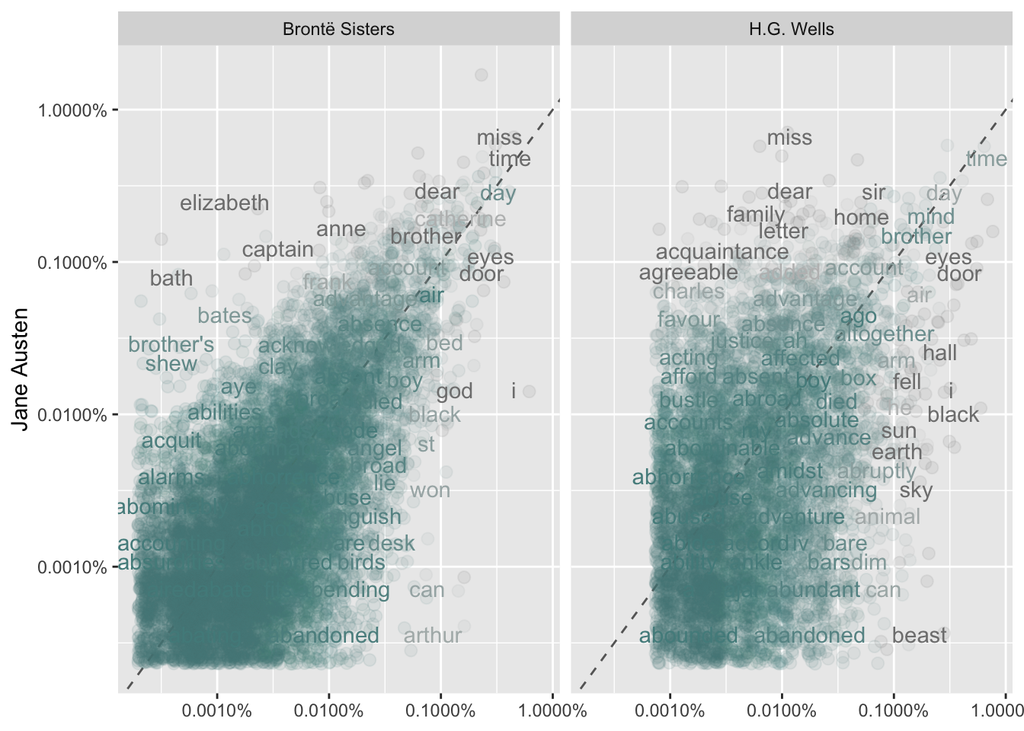

```r
library(scales)
ggplot(frequency, aes(x = proportion, y = `Jane Austen`,
                      color = abs(`Jane Austen` - proportion))) + # gradiente que indica la proporción
  geom_abline(color = "gray40", lty = 2) +
  geom_jitter(alpha = 0.1, size = 2.5, width = 0.3, height = 0.3) +
  geom_text(aes(label = word), check_overlap = TRUE, vjust = 1.5) +
  scale_x_log10(labels = percent_format()) +# transformación para que se vea mejor
  scale_y_log10(labels = percent_format()) +# transformación para que se vea mejor
  scale_color_gradient(limits = c(0, 0.001),
                       low = "darkslategray4", high = "gray75") +
  facet_wrap(~author, ncol = 2) +
  theme(legend.position="none") +
  labs(y = "Jane Austen", x = NULL)
```

El gráfico permite ver cómo se relacionan (o no) las palabras entre las obras de estos autores. Esto además se puede cuantificar con correlaciones:

```r
cor.test(data = frequency[frequency$author == "Brontë Sisters",],
         ~ proportion + `Jane Austen`)
```

```
##
##  Pearson's product-moment correlation
##
## data:  proportion and Jane Austen
## t = 111.06, df = 10346, p-value < 2.2e-16
## alternative hypothesis: true correlation is not equal to 0
## 95 percent confidence interval:
##  0.7285370 0.7461189
## sample estimates:
##       cor
## 0.7374529
```

```r
cor.test(data = frequency[frequency$author == "H.G. Wells",],
         ~ proportion + `Jane Austen`)
```

```
##
##  Pearson's product-moment correlation
##
## data:  proportion and Jane Austen
## t = 35.229, df = 6008, p-value < 2.2e-16
## alternative hypothesis: true correlation is not equal to 0
## 95 percent confidence interval:
##  0.3925914 0.4345047
## sample estimates:
##       cor
## 0.4137673
```

Estos resultados indican que las palabras usadas por las hermanas Brontë correlacionan más con aquellas usadas por Jane Austen, en comparación con HG Wells.